# Data Science With an Eye Towards Sustainability P5: Narrowing Your Project Topic

Becca, Camille, Sally, Noah, Sherry

```r
# Packages
if (!"pacman" %in% installed.packages()){
  install.packages("pacman")
}
#load pacman
library(pacman)
```

```r
pacman::p_load("forcats","dplyr","readr","ggplot2")
```

Each group should hand in one html document for the following exercises. Throughout the exercises, keep in mind that your research topics, questions, and data might evolve throughout the course of the project. This checkpoint is simply a first step in narrowing these down.

# 1 Names & Workflow

List all group members. Discuss a plan for completing this assignment. How will you put together your shared Rmd? How will you divide the work? When will you meet to work on the assignment? Write this down in your Rmd.

- Try to get most things done in class, and weekly meeting some time during Wednesday afternoon (probably 3 or 4 pm) to check in and have a little bit of co-working time.
- If asynchronous work needs to be done, the work wpuld be assigned to members during in-person meetings

Also, write down your GitHub repository. - olincollege/mbta-data

# 2 Topic & Research Questions

Following on the conversations you’ve already had in the preliminary brainstorming exercises, identify a common research topic of interest.

- Buses, its ridership, and its use of fuel, its schedule/delays

Specify two to three potential research questions that (1) are related to the topic above; and (2) you can (at least partially) answer using data.

- What factors affect mbta light rail ridership (COVID lockdown, day of the week, time of day, etc)?
- How to quantify the environmental and social sustainability of the light rail (carbon emission per person)?

# 3 Connections to Sustainability

How are your research questions connected to sustainability? What are your personal learning goals related to sustainability for this project? You may wish to refer back to the [UN Sustainable Development Goals](https://sdgs.un.org/goals), the [Inner Development Goals](https://innerdevelopmentgoals.org/), and the [Engineering for One Planet](https://engineeringforoneplanet.org/wp-content/uploads/EOP_Framework_2023.pdf?), [Six Pillars of Climate Justice](https://centerclimatejustice.universityofcalifornia.edu/what-is-climate-justice/), and [Just Transition Principles](https://climatejusticealliance.org/just-transition/) frameworks. As a team, what sustainability background, analysis, and storytellling do you want to include in the scope of your project and in your final artifacts?

- Looking at the MBTA schedule and emissions tie into SDG 11 and its target to provide accessible and sustainable transport systems for all.
- Personally, this project would provide us with insights about the issues and benefits surrounding public transport so we could better advocate for it.

# 4 Data

Identify the data sets you will use to explore the research questions above. These data sets may already be in csv form, you may acquire them (e.g., scraped with rvest, via public API, or from an SQL database), or you may plan on collecting some extra data. For each data set, summarize the following:

- data source: MBTA Gated Station Entries - Historical
- data description - what’s being measured?: The count of gated station entries for each day for multiple years broken up in 30 minute increments
- data limitations (eg: are the data recent? do they contain all variables you might want?): The most recent data is two months old. This only contains ridership data for days and not data on any of the other things we are looking into.
- data dimensions - how much data do you have?: There are eleven csv files dating back to 2014. Each pof them has at least a million entries of six variables (excel won’t show the entire thing)
- how might the data be joined with other data you have?: date, time, and type of transportation could be combined with other data.
- data source: MBTA fuel and energy
- data description - what’s being measured?: The volume, miles traveled and efficiency of different energy sources used by the MBTA for different services over time.
- data limitations (eg: are the data recent? do they contain all variables you might want?): This was most recently updated in 2021. It does not contain information on ridership, but it can be extrapolated by the miles traveled.
- data dimensions - how much data do you have?: 288 observations of 8 variables
- how might the data be joined with other data you have?: year and type of transportation could be combined with other data.

# 5 Research Question 1

Restate research question 1. Construct 3-4 relevant visualizations that provide insight on / help answer this question and piece these together to tell a short story. For each visualization, 1-2 sentences will suffice.

How to quantify the environmental and social sustainability of the light rail (carbon emission per person)?

```r
energy = read_csv("Fuel_and_Energy.csv")
```

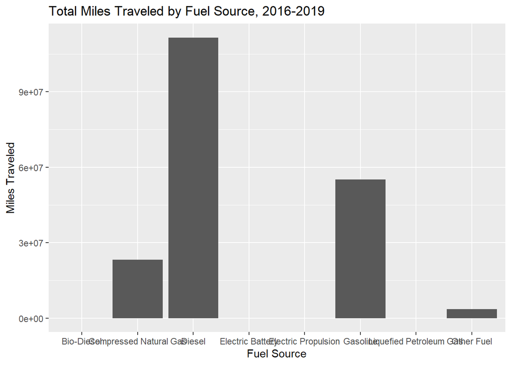

```r
by_fuel = energy %>%
  group_by(Fuel_Source) %>%
  summarize(total_miles = sum(Miles_Traveled), total_vol = sum(Volume))

ggplot(by_fuel, aes(x=Fuel_Source, y=total_miles)) +
  geom_col() +
  labs(title="Total Miles Traveled by Fuel Source, 2016-2019", x="Fuel Source", y="Miles Traveled")
```

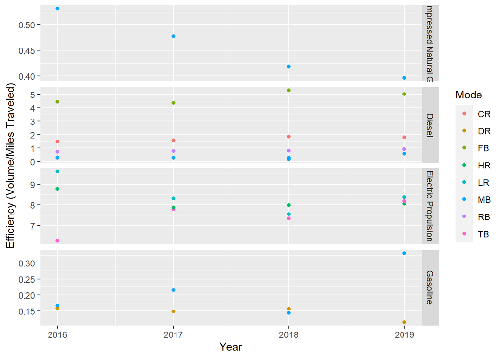

```r
energy_data <- read.csv("Fuel_and_Energy.csv") %>%
  filter(Volume > 0, Miles_Traveled != "NA") %>%
  select(-Efficiency, -ObjectId) %>%
  mutate(Efficiency = Volume/Miles_Traveled) %>%
  group_by(Mode, Units)



ggplot(energy_data, aes(x=Year, y=Efficiency)) +
  geom_point(aes(color=Mode)) +
  facet_grid("Fuel_Source", scales = "free_y") +
  labs(y="Efficiency (Volume/Miles Traveled)")
```

```r
  theme()
```

```
##  Named list()
##  - attr(*, "class")= chr [1:2] "theme" "gg"
##  - attr(*, "complete")= logi FALSE
##  - attr(*, "validate")= logi TRUE
```

it seems that the use of a gasoline has changed in efficiency over time, becoming more efficient an compressed natural gas is less efficient.

# 6 Research Question 2 (and possibly 3)

Repeat the previous exercise for your second and possibly third research questions.

What factors affect mbta light rail ridership (COVID lockdown, day of the week, time of day, etc)?

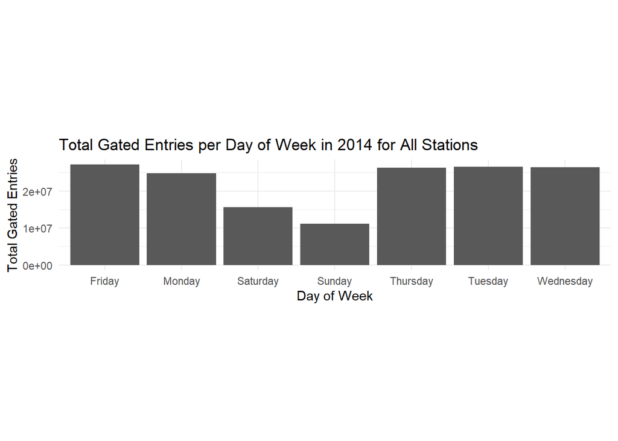

```r
# Load required library
library(ggplot2)

# Read the CSV file
df <- read.csv("GSE_by_year/GSE_2014.csv")
df$service_date <- as.Date(df$service_date)

# Convert the 'service_date' column to Date format
df$service_day <- weekdays(df$service_date)

# Aggregate the data by date and calculate the sum of entries for each date
df_sum_day <- df %>%
  group_by(service_day) %>%
  summarise(total_entries = sum(gated_entries))

# Create a line plot of sum of entries per date for all stations
ggplot(df_sum_day, aes(x = service_day, y = total_entries)) +
  geom_col() +
  labs(x = "Day of Week", y = "Total Gated Entries",
       title = "Total Gated Entries per Day of Week in 2014 for All Stations") +
  theme_minimal() +
  theme(aspect.ratio = 1 / 5)
```

MBTA usage drops by around half on weekends, and is lower on Monday than other weekdays.

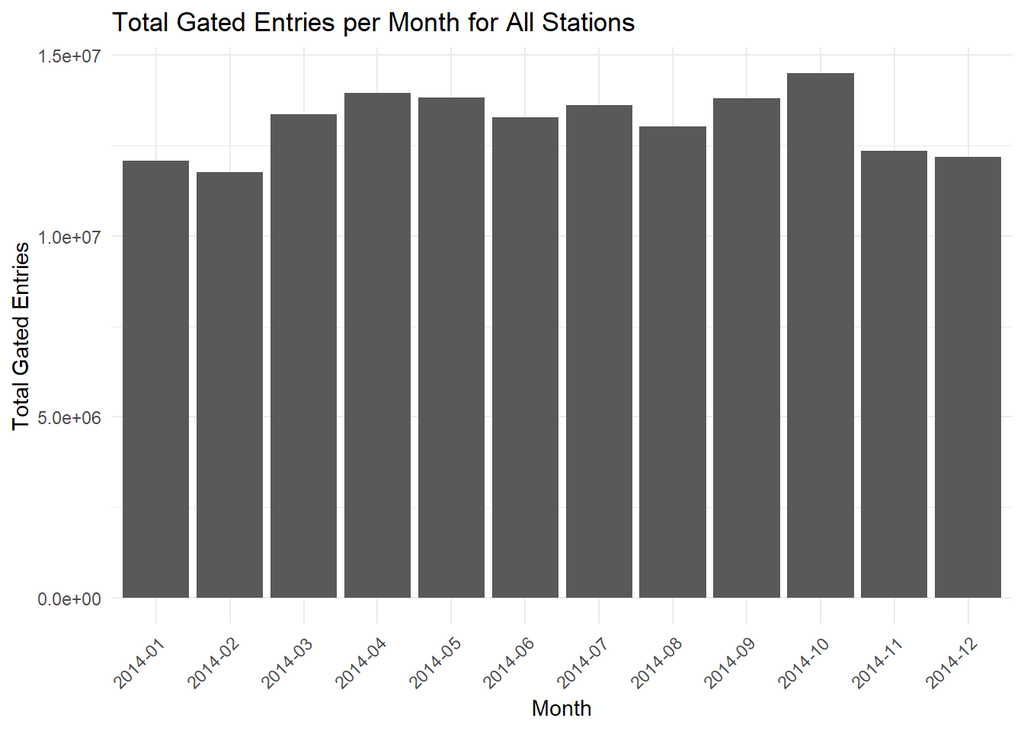

```r
# Extract month from the 'service_date' column
df$month <- format(df$service_date, "%Y-%m")

# Aggregate the data by month and calculate the sum of entries for each month
df_sum <- df %>%
  group_by(month) %>%
  summarise(total_entries = sum(gated_entries))

# Create a line plot of sum of entries per month for all stations
ggplot(df_sum, aes(x = month, y = total_entries)) +
  geom_col() +
  labs(x = "Month", y = "Total Gated Entries",
       title = "Total Gated Entries per Month for All Stations") +
  theme_minimal() +
  theme(axis.text.x = element_text(angle = 45, hjust = 1))
```

There is fairly limited variance between the months, although there is somewhat of a decrease in the colder months.

```r
library(dplyr)
```

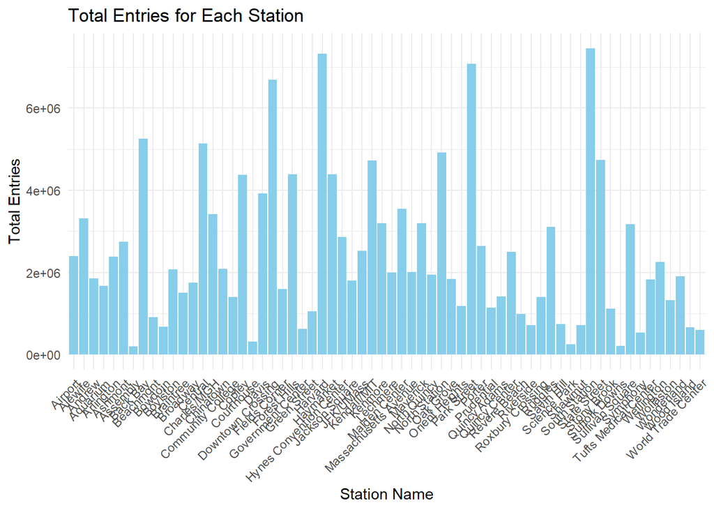

```r
# Aggregate the data by station and calculate the sum of entries
df_station_sum <- df %>%
  group_by(station_name) %>%
  summarise(total_entries = sum(gated_entries))

# Create a bar graph of total entries for each station
ggplot(df_station_sum, aes(x = station_name, y = total_entries)) +
  geom_bar(stat = "identity", fill = "skyblue") +
  labs(x = "Station Name", y = "Total Entries",
       title = "Total Entries for Each Station") +
  theme_minimal() +
  theme(axis.text.x = element_text(angle = 45, hjust = 1))
```

There is a large amount of variance between the stations, much more than any of the time factors.

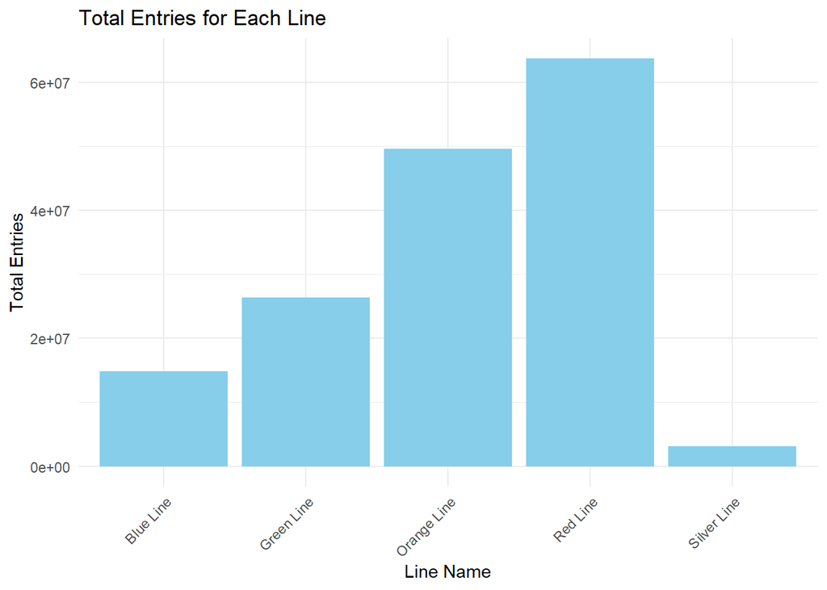

```r
# Aggregate the data by line and calculate the sum of entries for January
df_line_sum <- df %>%
  group_by(route_or_line) %>%
  summarise(total_entries = sum(gated_entries))

# Create a bar graph of total entries in January for each station
ggplot(df_line_sum, aes(x = route_or_line, y = total_entries)) +
  geom_bar(stat = "identity", fill = "skyblue") +
  labs(x = "Line Name", y = "Total Entries",
       title = "Total Entries for Each Line") +
  theme_minimal() +
  theme(axis.text.x = element_text(angle = 45, hjust = 1))
```

There’s a lot of variance between the lines, and perhaps that explains part of the variance between stations. The silver line is also barely used compared to the others, which is interesting.

# 7 Next Steps

Identify next steps in your analysis. Do you need additional data? Do you need to do more cleaning or wrangling? How might you narrow your research questions/hypotheses? What additional visualizations would be helpful?

we could gather more data about economic distribution across gated stations and or routes. The visualizations help to allow us to see what aspects of these questions should be pursued, such as comparing gated entries to total ridership data.

# 8 Contributions

Summarize each group member’s specific contributions to this checkpoint assignment.

we collectively worked on the first portion of the assignment then split to create our visualizations.